# Projet Information de Brevet

# Introduction

*Créé en 2011, BOOSTHEAT est un acteur de la filière de l’efficacité énergétique. La Société a pour mission d’accélérer la transition écologique grâce à l’intégration de sa technologie dans des applications fortement consommatrices d’énergie. BOOSTHEAT a conçu et développé un compresseur thermique protégé par 7 familles de brevets permettant d’optimiser significativement la consommation d’énergie pour tendre vers une utilisation raisonnable et pertinente des ressources. La Société est labellisée Entreprise Innovante (Bpifrance) et French Fab. BOOSTHEAT est cotée sur Euronext Growth à Paris, (ISIN : FR0011814938).*

*Ce rapport vous présente l’activité inventive de l’entreprise Boostheat en mobilisant les données de brevets extraites depuis Patstat. Les données statistiques permettent d’identifier le dynamise du secteur, la zone géographique où l’entreprise a fait plus de demandes de brevets et de faire d’analyse sur la citation des brevets.*

# I. Données

*Nous avons extrait nos données depuis PATSAT en appliquant des requêtes SQL. Au final, nous avons extrait 6 tables en csv que nous avons regroupés dans une base de données.*

*Question 1 : Lister les brevets déposés par les firmes*

*Question 2a : Classe technologiques IPC associés à ces brevets*

*Question 2b : Classe technologiques CPC associés à ces brevets*

*Question 3a : Lister les citations reçues par ces brevets*

*Question 3b : Lister les citations reçues par ces brevets en ajoutant les classes des brevets citant*

*Question4 : Renouvellement des brevets français*

# II. Analyse des données

## 1. Analyse de la Table1

```r
library(ggplot2)
library(readr)
tab1= read.csv("question 1.csv",header = TRUE,sep = ";")
summary(tab1)
```

```
##   ï..appln_id         appln_auth        appln_filing_year docdb_family_id
##  Min.   :341415012   Length:48          Min.   :2012      Min.   :45562351
##  1st Qu.:420380991   Class :character   1st Qu.:2013      1st Qu.:47553222
##  Median :450819113   Mode  :character   Median :2014      Median :49237254
##  Mean   :459411622                      Mean   :2014      Mean   :50938842
##  3rd Qu.:500603398                      3rd Qu.:2016      3rd Qu.:55072925
##  Max.   :539583674                      Max.   :2020      Max.   :67514775
##    granted            han_name
##  Length:48          Length:48
##  Class :character   Class :character
##  Mode  :character   Mode  :character
##
##
##
```

```r
table(tab1$appln_auth)
```

```
##
## CA CN DK EP ES FR IN JP TR US WO
##  6  6  4  6  3  6  1  1  2  6  7
```

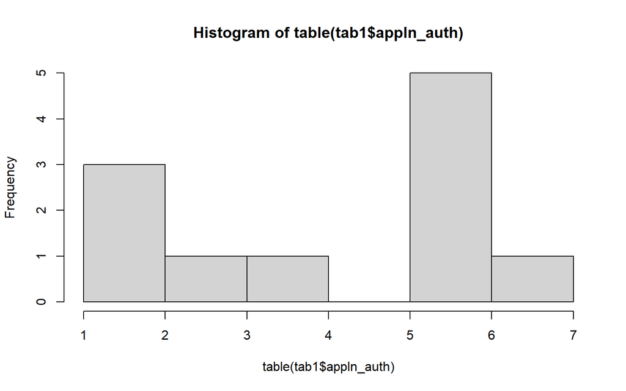

```r
# l'entreprise dispose de 48 brevets déposé dans diffrents office.
hist(table(tab1$appln_auth))
```

```r
table(tab1$appln_auth)
```

```
##
## CA CN DK EP ES FR IN JP TR US WO
##  6  6  4  6  3  6  1  1  2  6  7
```

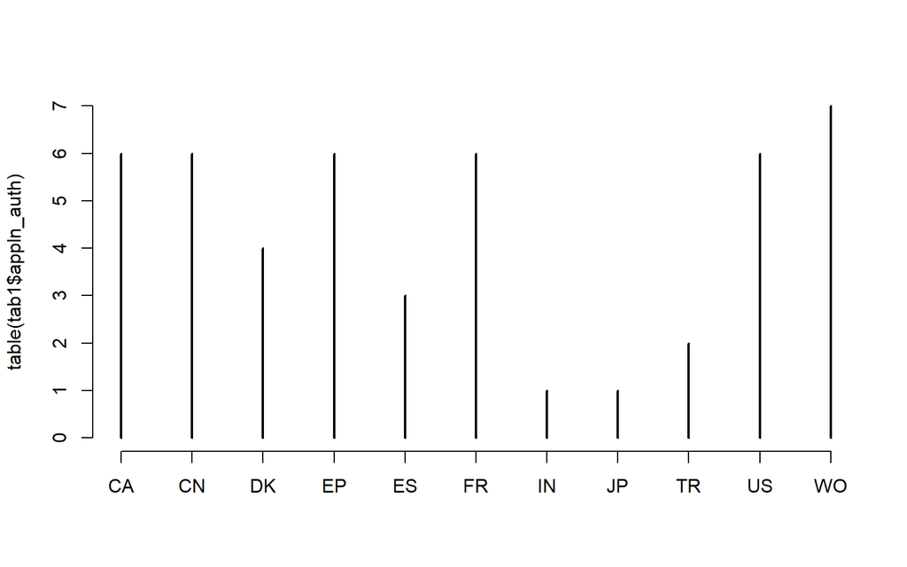

```r
plot(table(tab1$appln_auth))
```

```r
table((tab1$granted),tab1$appln_auth)
```

```
##
##     CA CN DK EP ES FR IN JP TR US WO
##   N  4  1  0  2  0  1  1  0  0  0  7
##   Y  2  5  4  4  3  5  0  1  2  6  0
```

```r
table((tab1$granted),tab1$appln_filing_year)
```

```
##
##     2012 2013 2014 2015 2016 2017 2018 2019 2020
##   N    1    1    4    1    3    0    4    1    1
##   Y    7    9   10    1    2    1    2    0    0
```

```r
table((tab1$docdb_family_id),(tab1$granted),(tab1$appln_filing_year))
```

```
## , ,  = 2012
##
##
##            N Y
##   45562351 1 6
##   47553222 0 1
##   49237254 0 0
##   49474542 0 0
##   55072925 0 0
##   59297038 0 0
##   67514775 0 0
##
## , ,  = 2013
##
##
##            N Y
##   45562351 0 0
##   47553222 1 7
##   49237254 0 1
##   49474542 0 1
##   55072925 0 0
##   59297038 0 0
##   67514775 0 0
##
## , ,  = 2014
##
##
##            N Y
##   45562351 0 0
##   47553222 0 0
##   49237254 2 5
##   49474542 2 5
##   55072925 0 0
##   59297038 0 0
##   67514775 0 0
##
## , ,  = 2015
##
##
##            N Y
```

[output cut: 52 more lines]

```
##   55072925 0 0
##   59297038 0 0
##   67514775 1 0
##
## , ,  = 2020
##
##
##            N Y
##   45562351 0 0
##   47553222 0 0
##   49237254 0 0
##   49474542 0 0
##   55072925 0 0
##   59297038 0 0
##   67514775 1 0
```

*Si nous observons le nombre de brevet octroyé par année, nous constatons que l’entreprise a effectué plus de demande de brevet en 2014 (14 brevets) dont 10 ont été acceptés et 4 refusés.*

## 2. Analyse de la table 2

### i. Analyse de la table 2a

```r
tab2a <- read.csv("question 2a.csv",header = TRUE,sep = ";")
summary(tab2a)
```

```
##   ï..appln_id        Ipc_class_symbol
##  Min.   :341415012   Length:120
##  1st Qu.:437189342   Class :character
##  Median :470918069   Mode  :character
##  Mean   :464527502
##  3rd Qu.:502014375
##  Max.   :539583674
```

```r
table(tab2a$Ipc_class_symbol)
```

```
##
## F01B F02G F04B F24D F24H F25B G01D G01K G06Q
##    9   12   29   17    9   29    6    2    7
```

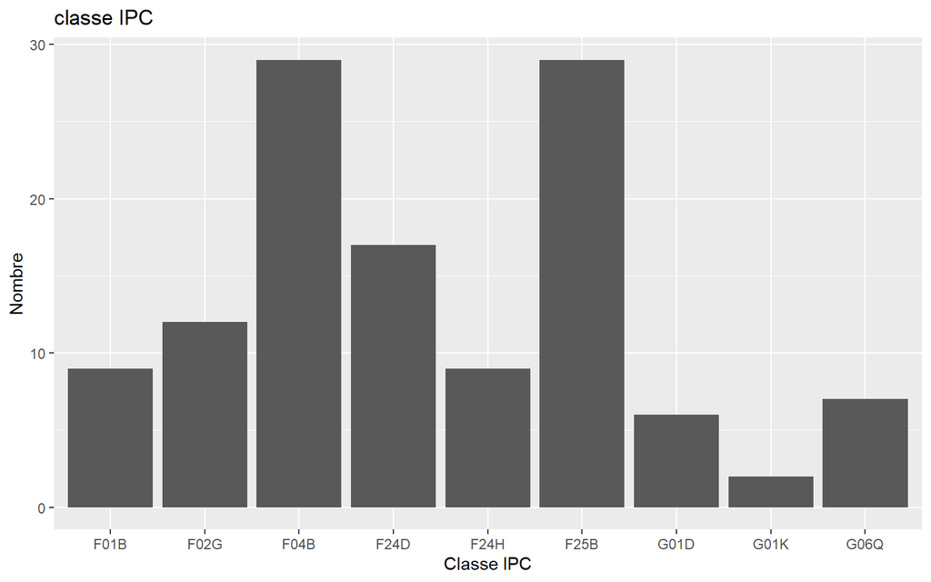

```r
# Hist ipc
ggplot(data.frame(tab2a$Ipc_class_symbol), aes(x=tab2a$Ipc_class_symbol))+
  geom_bar()+
  labs(title="classe IPC", x="Classe IPC", y="Nombre")
```

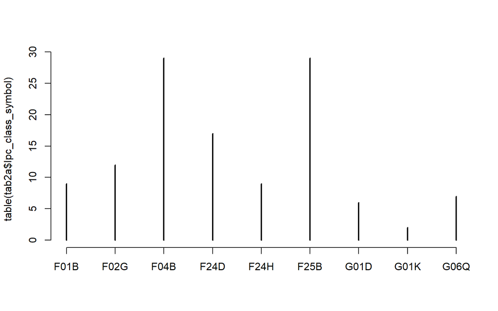

```r
plot(table(tab2a$Ipc_class_symbol))
```

*La classification internationale des brevets ou CIB est un système hiérarchique de classement des brevets selon les différents domaines technologiques auxquels ils appartiennent. Nous constatons que l’entreprise intervient pour ses demandes de brevets que sur ces 2 domaines suivants :*

*- MÉCANIQUE; ÉCLAIRAGE; CHAUFFAGE; ARMEMENT; SAUTAGE* *- MÉTROLOGIE; TESTS.*

*Cependant, le domaine où l’entreprise effectue beaucoup plus de demande de brevet est dans le domaine MÉCANIQUE; ÉCLAIRAGE; CHAUFFAGE; ARMEMENT; SAUTAGE sous classe MACHINES MOTRICES, MOTEURS OU POMPES dont les classes exactes sont F04B et F25B.*

*En effet, Ces demandes de brevet dans ces domaines s’explique par le fait que Boostheat connu comme le fabricant des chaudières écologiques a pour objectif de développer un nouveau modèle énergétique visant in fine à diminuer l’impact du chauffage sur la planète et ceci en investissant leur énergie pour développer une pompe à chaleur qui repose sur le principe de la compression thermique.*

### ii. Analyse de la table 2b

```r
tab2b=read.csv("question 2b cpc.csv",header=TRUE,sep=";")
summary(tab2b)
```

```
##   ï..appln_id        cpc_class_symbol
##  Min.   :341415012   Length:140
##  1st Qu.:437189342   Class :character
##  Median :470684176   Mode  :character
##  Mean   :462509616
##  3rd Qu.:497726170
##  Max.   :539583674
```

```r
table(tab2b$cpc_class_symbol)
```

```
##
## F01B F02G F04B F24D F24H F25B G01K G06Q Y02B
##   10   20   30   19   11   23    8    8   11
```

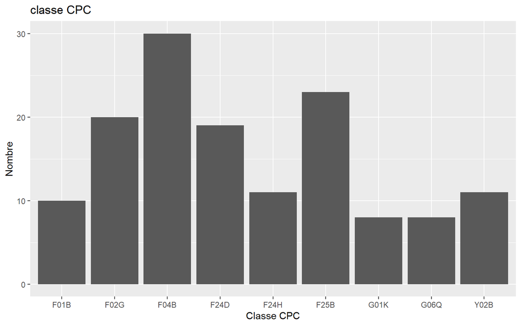

```r
# Hist cpc
ggplot(data.frame(tab2b$cpc_class_symbol), aes(x=tab2b$cpc_class_symbol))+
  geom_bar()+
  labs(title="classe CPC", x="Classe CPC", y="Nombre")
```

## 3. Analyse de la table 3

### i. Analyse de la table 3a

*Une analyse en excel en faisant 2 tableaux dynamique croisé des identifiants de brevet et de leur famille. En effet, on a fait le comptage brut des identiants de brevet pour voir combien de fois le brevet a été cité (n_citn). Nous avons fait la correction des autocitations (n_citn2) et enfin determiner les citations faites aux inventions (n_citn3)*

*L’analyse montre :*

*-d’après le premier tableau dynamique croisé,*

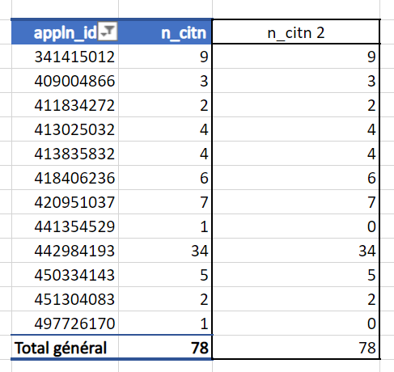

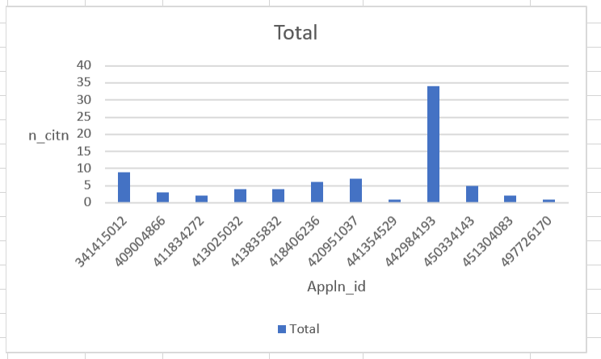

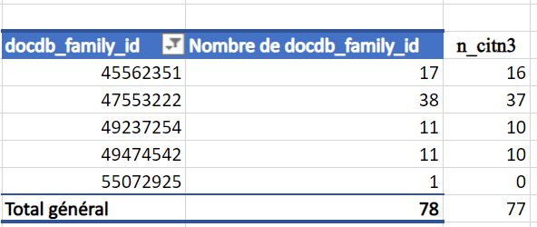

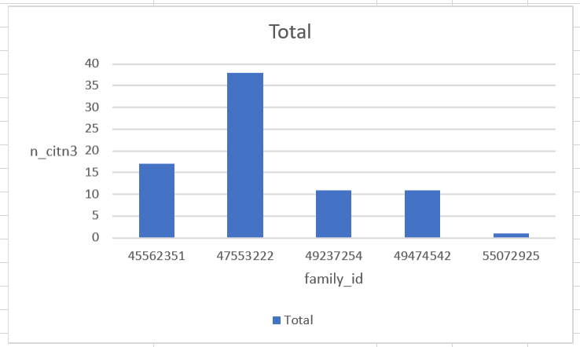

*on constate en faisant le comptage brut des identiiants des brevets, le brevet 442984193 est celui qui est le plus cités dans les inventions. Il est appartient à la famille de brevet dont l’identifiant est 47553222. Par contre, nous avons 2 brevets qui n’ont pas été cités dont l’un 441354529 appartient à la famille 47553222 et l’autre 497726170 à la famille 55072925.*

### ii. Analyse de la table 3b

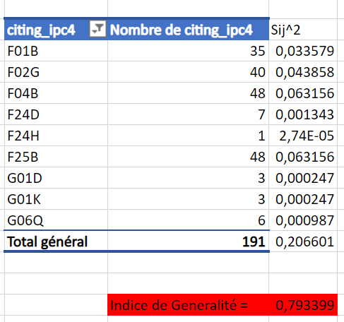

## 4. Analyse de la table 4

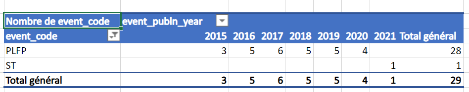

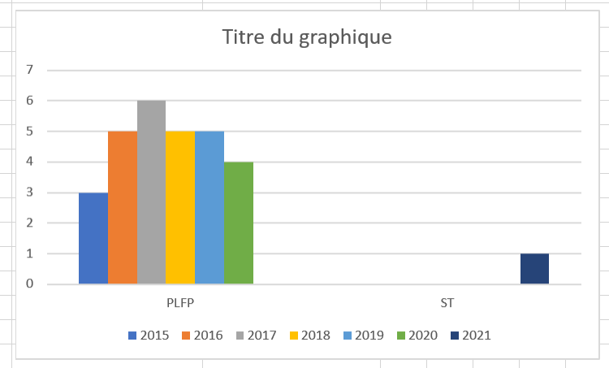

# Conclusion

*Les brevets sont un élément fondamental de la création de valeur à partir des innovations. D’après nos resultats, Boostheat a concentrer la majeure partie de ses efforts internes sur son innovation, par exemle son compresseur thermique protégé par 7 familles de brevets qui réduisent significativement la consommation d’énergie pour favoriser une utilisation raisonnable et pertinente des ressources. Cependant, nous constatons ces dernières années une dimunition de ces demandes brevets, ce qui peut lui creer des situations très difficiles à tenir face à une vive concurrence.*